# Lab 6: Ordinal Logistic Regression with the Big Five

## 7.4 Shared and Threshold-Specific Odds Ratios

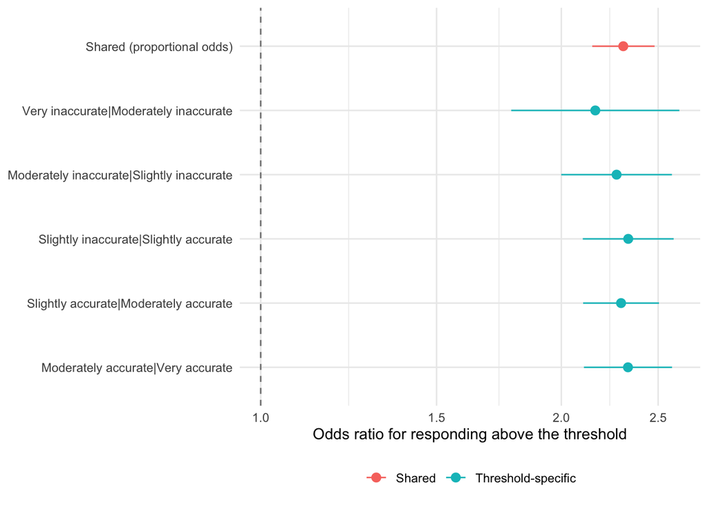

Figure 2: Shared and threshold-specific cumulative odds ratios for Extraversion.

```r
bind_rows(
  tibble(
    Threshold = "Shared (proportional odds)",
    OR = or_tab$estimate,
    low = or_tab$conf.low,
    high = or_tab$conf.high,
    Model = "Shared"
  ),
  threshold_or
) |>
  mutate(Threshold = fct_rev(fct_inorder(Threshold))) |>
  ggplot(aes(OR, Threshold, colour = Model)) +
  geom_vline(xintercept = 1, linetype = "dashed", colour = "grey50") +
  geom_pointrange(aes(xmin = low, xmax = high)) +
  scale_x_log10() +
  labs(x = "Odds ratio for responding above the threshold",
       y = NULL, colour = NULL) +
  theme_minimal() +
  theme(legend.position = "bottom")
```

The threshold-specific odds ratios clustered around the shared estimate, and all confidence intervals lay above one. This pattern was consistent with the likelihood-ratio test and supported retaining a common slope across cutpoints.

# Part 8. Findings and Limitations

I fit a cumulative logit model predicting responses to “Know how to comfort others” from mean-centred Extraversion (*N* = 2,694). The smallest response category contained 88 observations, and all categories were retained. Adding Extraversion improved fit over the threshold-only model, χ²(1) = 558.33, *p* < .001, and reduced AIC by 556.33. Each one-point increase in Extraversion was associated with 130.7% higher odds of responding above any given cutpoint, *OR* = 2.31, 95% CI [2.15, 2.48], *p* < .001. Allowing the slope to vary across cutpoints did not significantly improve fit, χ²(4) = 0.84, *p* = .934, so I retained the proportional-odds model.

The predicted probability of responding *Slightly accurate* or higher was 31.4% at an Extraversion score of 1 and 96.8% at a score of 6 (see Figure 1). A3 measures how people describe their ability to comfort others, and the analysis did not assess how they respond when someone is distressed. Both measures were self-reported, and the observational design limits the conclusion to an association. Within these limits, the results supported the prediction that higher Extraversion would be associated with stronger endorsement of the item.